# Job Posting Data Analysis Report

Experience, Programming Languages, and Salary Trends

Data Analysis Workshop

2026-02-04

# Introduction

This project analyzes job posting data from the data science field, examining 400 positions to explore the relationship between candidate experience requirements, programming language skills (R, Python, both, or neither), and median salary estimates. The analysis aims to identify trends and patterns that could inform career development decisions in the data analytics sector.

# Data Analysis

## Relationship Between Experience and Salary

The following scatter plot examines the relationship between minimum years of experience required and median salary estimates across job postings.

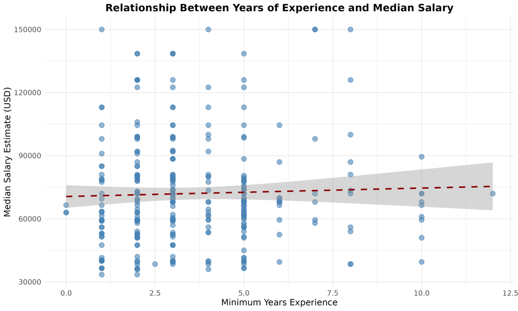

Scatter plot showing the relationship between minimum years of experience and median salary estimates. The dashed red line represents the linear regression trend.

## Salary Distribution by Programming Language

The box plot below compares median salary distributions across different programming language requirements.

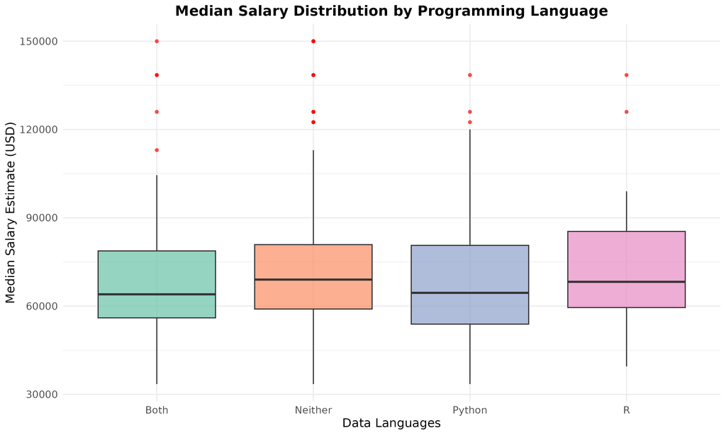

Box plot comparing median salary distributions by programming language category (R, Python, Both, Neither).

# Reflection

## What was easy or difficult?

This exercise was relatively straightforward and easily transferable to professional practice. However, I encountered a major limitation: Google Sheets is not accessible in my professional environment. This necessitated creating VBA macros for Excel to replicate the functionality. This is not insurmountable, as AI can easily assist us in creating these macros. The use of a MYGPT-type function is particularly relevant for enriching a row of data in a table. It would also be interesting to consider how to use this type of function to leverage LLMs in a more vertical manner—that is, by executing a prompt that would analyze the cumulative and aggregated data from our entire dataset.

## What was surprising or noteworthy?

I was very surprised to see the difference in results displayed when isolating the number of years of candidate experience using different LLM models. For one specific case, the google/gemini-2.5-flash-lite model indicated 24 years instead of 24 months, while the gemini-2.5 model indicated 10 years. This reminds me of the importance of cross-checking data with different models to avoid integrating biases into our analysis.

## What did you learn?

I learned here that it is possible to add very interesting and relevant functionalities to our everyday work tools. I wish to transpose this into my practice and share it with my colleagues.

# Conclusion